# KNN

Vazgen Tadevosyan

April 18, 2019

*You are required to submit both Markdown and HTML files. Data set (Spam E-mail Data) relevant for this assignment can be found in the R package “DAAG”.*

Problem 1 (10 pt.)

- 1. Suppose the sysadmin wants to understand and predict the process of recognizing the emails as spam for new e-mails which make up 20% of your initial data. Compare the performance of the logit and k-NN for classification on your data. Which one is better? Why? (Use the ROC curve to find the best cutoff value and cross-validation for choosing the value of k. Show both results graphically).
- 2. What are the differences **(at least 3)** of these algorithms (in general)?

```r
library(ROCR)
library(ggplot2)
library(gridExtra)
library(ggcorrplot)
library(DAAG)
library(caret)
library(pROC)
library(class)
library(BBmisc)
data("spam7")
addmargins(table(spam7$yesno))
```

```
##
##    n    y  Sum
## 2788 1813 4601
```

```r
set.seed(1)
train_index<-createDataPartition(spam7$yesno,p = 0.7,list = F)
train<-spam7[train_index,]
test<-spam7[-train_index,]
##Logit
logit<-glm(yesno~.,data = train,family = 'binomial')
predicted<-predict(logit,test,type = "response")
predicted1<-ifelse(predicted>0.5,"y","n")
confusionMatrix(factor(predicted1),test$yesno,positive = "y")
```

```
## Confusion Matrix and Statistics
##
##           Reference
## Prediction   n   y
##          n 801 194
##          y  35 349
##
##                Accuracy : 0.8339
##                  95% CI : (0.8132, 0.8532)
##     No Information Rate : 0.6062
##     P-Value [Acc > NIR] : < 2.2e-16
##
##                   Kappa : 0.6334
##  Mcnemar's Test P-Value : < 2.2e-16
##
##             Sensitivity : 0.6427
##             Specificity : 0.9581
##          Pos Pred Value : 0.9089
##          Neg Pred Value : 0.8050
##              Prevalence : 0.3938
##          Detection Rate : 0.2531
##    Detection Prevalence : 0.2785
##       Balanced Accuracy : 0.8004
##
##        'Positive' Class : y
##
```

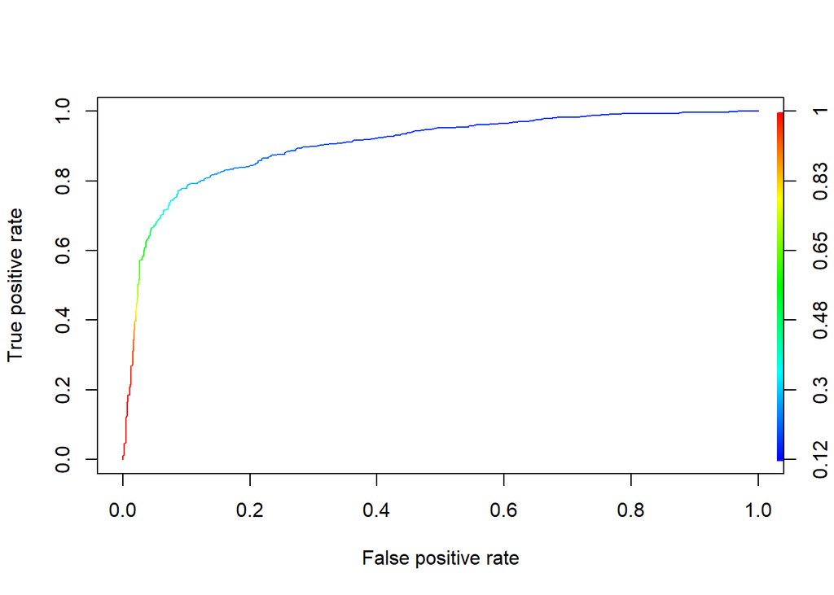

```r
R1<-ifelse(predicted1=="y",1,0)
R2<-ifelse(test$yesno=="y",1,0)
rrr1<-roc(R2,R1)
g1<-ggroc(rrr1,alpha = 0.5, colour = "green", linetype = 1, size = 1)+ggtitle("ROC curve for Model Logistic")

P_test<-ROCR::prediction(predicted,test$yesno)
perf<-performance(P_test,'tpr','fpr')
plot(perf,colorize=T)
```

```r
performance(P_test,'auc')@y.values
```

```
## [[1]]
## [1] 0.9043899
```

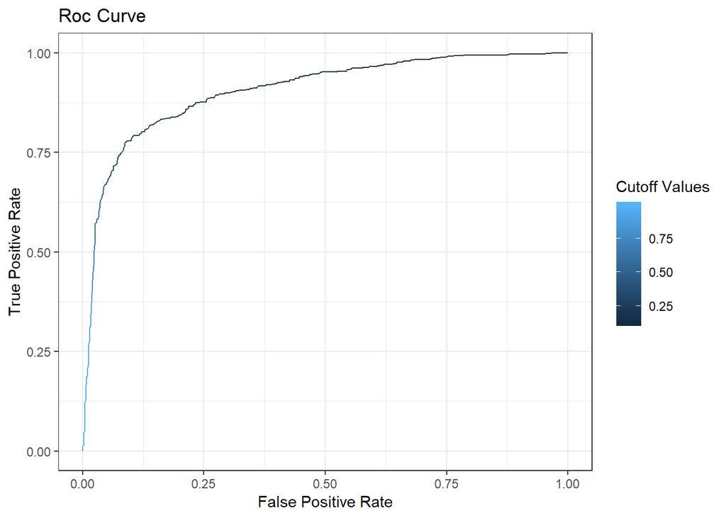

```r
FPR<-unlist(perf@x.values)
TPR<-unlist(perf@y.values)
alpha=unlist(perf@alpha.values)
df<-data.frame(FPR,TPR,alpha)
ggplot(df,aes(x=FPR,y=TPR,color=alpha)) + geom_line()+
  theme_bw()+ labs(x="False Positive Rate",y="True Positive Rate",title="Roc Curve",color="Cutoff Values")
```

```r
##KNN
data("spam7")

spam7$crl.tot<-scale(spam7$crl.tot)
set.seed(1)
train_index<-createDataPartition(spam7$yesno,p = 0.7,list = F)
train<-spam7[train_index,]
test<-spam7[-train_index,]
crtl<-trainControl(method = "cv",number = 5)
```

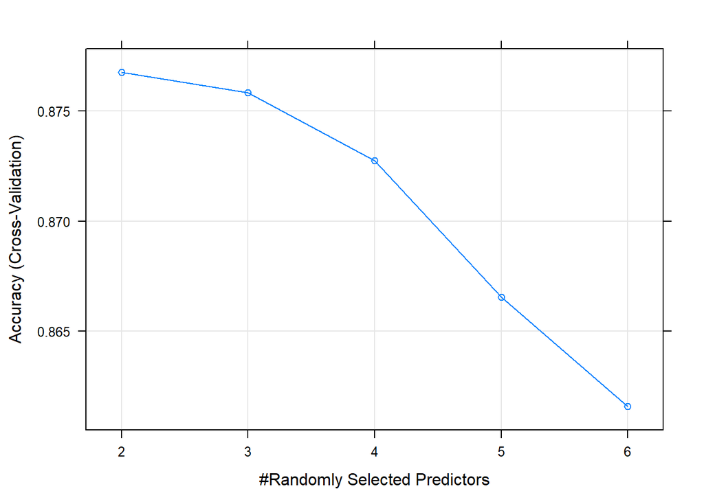

```r
knn_c<-train(yesno~.,data=train,trControl=crtl,tuneLength=5)
plot(knn_c)
```